# Generalised Linear Models

Count & Rate data

Philip Leftwich

University of East Anglia

2026-02-12

# Introduction

## Learning Objectives

By the end of this session, you will be able to:

1. Explain why model assumptions are important
2. Fit appropriate models to rate/count data
3. Evaluate models for best fit
4. Deliver transparent and clear reporting

# Recap

## What have you learned so far?

- Tell me one thing you appreciate or understand more about coding, data exploration and version control
- Tell me one thing you don’t quite understand or want to check?

# Fitting a Linear Model

## Cuckoo data

## Visualising Data

- Mass: nestling mass of chick in grams
- Beg: begging calls per 6 secs
- Species: Warbler or Cuckoo

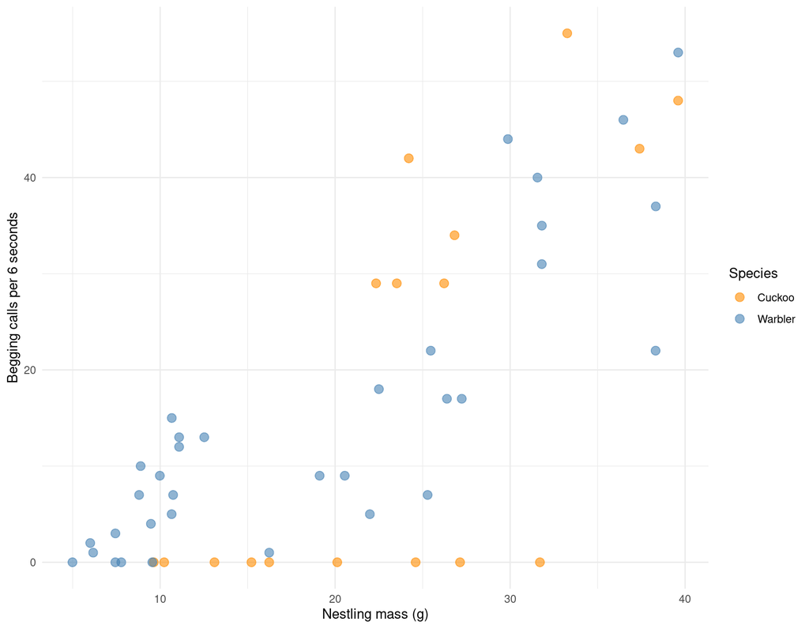

## Linear Model

```
Call:
lm(formula = Beg ~ Mass * Species, data = cuckoo)

Residuals:
     Min       1Q   Median       3Q      Max
-31.4366  -5.3476   0.8151   5.8992  22.8429

Coefficients:
                    Estimate Std. Error t value Pr(>|t|)
(Intercept)         -20.5057     7.7542  -2.644   0.0111 *
Mass                  1.6384     0.3086   5.310 2.93e-06 ***
SpeciesWarbler       14.1325     8.5983   1.644   0.1069
Mass:SpeciesWarbler  -0.4891     0.3530  -1.386   0.1724
---
Signif. codes:  0 '***' 0.001 '**' 0.01 '*' 0.05 '.' 0.1 ' ' 1

Residual standard error: 10.95 on 47 degrees of freedom
Multiple R-squared:  0.6116,    Adjusted R-squared:  0.5868
F-statistic: 24.67 on 3 and 47 DF,  p-value: 9.805e-10
```

## Evaluation

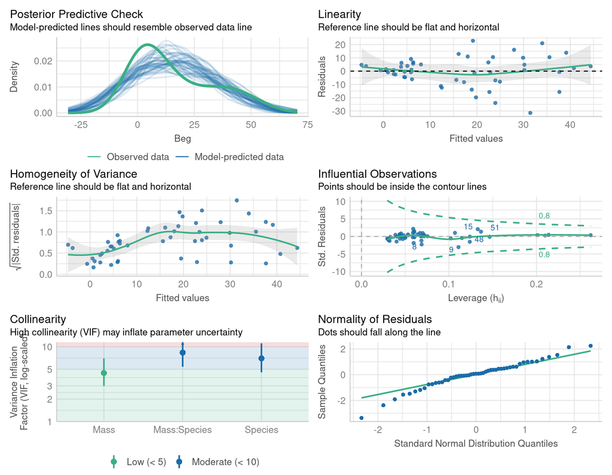

Figure 1

# GLMs for count data

## Linear models

Let’s start with linear models…

$y_i = \beta0 + \beta_1x1 + \beta_2x2 + ... +\beta_nxn +\epsilon_i$

$\epsilon_i = \mathcal{N}(0, \sigma^2)$

$y_i$ = individual data point

$\epsilon_i$ = Error distribution (here standard Normal)

## Generalised Linear models

Then generalised linear models…

$\mu_i = f(\beta0 + \beta_1x1 + \beta_2x2 + ... +\beta_nxn)$

$\epsilon_i \sim \mathcal{N}(0, \sigma^2)$

- $f$ is the link function to the mean

**Examples:** Log, sqrt, identity

- $\epsilon_i$ is the error term for observation $i$

**Examples:** Gaussian (normal), binomial, Poisson, gamma, etc.

## Poisson

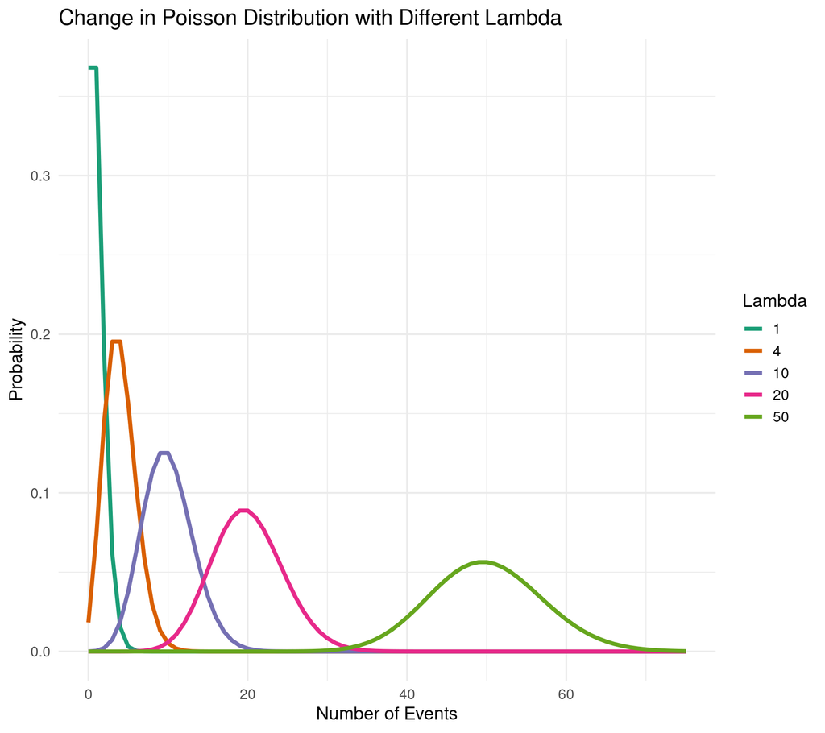

Count or rate data are ubiquitous in the life sciences (e.g number of parasites per microlitre of blood, number of species counted in a particular area). These type of data are **discrete** and **non-negative**.

A useful distribution to model abundance data is the **Poisson** distribution:

a discrete distribution with a single parameter, λ (lambda), which defines both the mean and the variance of the distribution.

## GLM

Recall the simple linear regression case (i.e a GLM with a Gaussian error structure and identity link). For the sake of clarity let’s consider a single explanatory variable where $\mu$ is the mean for *Y*:

$\mu_i = \beta0 + \beta_1x1 + \beta_2x2 + ... +\beta_nxn$

$y_i \sim \mathcal{N}(\mu_i, \sigma^2)$

- The mean function is **unconstrained**, i.e the value of $\beta_0 + \beta_1X$ can range from $-\infty$ to $+\infty$.

## Poisson

- If we want to model count data we therefore want to **constrain** this mean to be positive only.
- Mathematically we can do this by taking the **logarithm** of the mean (the log is the default link for the Poisson distribution).
- We then assume our count data variance to be Poisson distributed (a discrete, non-negative distribution), to obtain our Poisson regression model (to be consistent with the statistics literature we will rename $\mu$ to $\lambda$):

## GLM Poisson

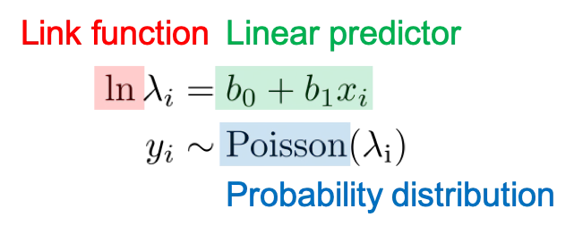

## Poisson distribution

The **Poisson** distribution has the following characteristics:

- **Discrete** variable (integer),

$$0, 1, \dots, \infty$$

- **Mean** = $\lambda$
- **Variance** = $\lambda$

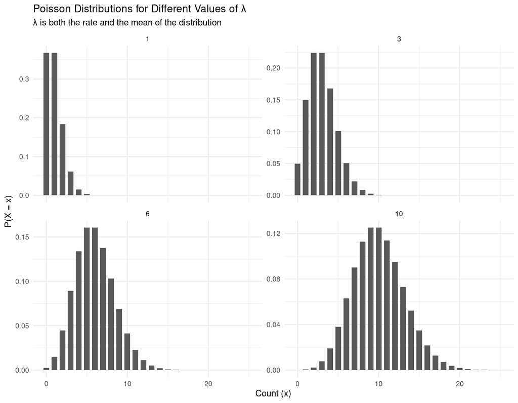

# Implementing a GLM

## Additive GLM

```r
cuckoo_glm_additive <- glm(Beg ~ Mass + Species, data = cuckoo,
                          family = poisson)

summary(cuckoo_glm_additive)
```

```
Call:
glm(formula = Beg ~ Mass + Species, family = poisson, data = cuckoo)

Coefficients:
               Estimate Std. Error z value Pr(>|z|)
(Intercept)    0.811318   0.121372   6.685 2.32e-11 ***
Mass           0.078835   0.003663  21.520  < 2e-16 ***
SpeciesWarbler 0.038744   0.072049   0.538    0.591
---
Signif. codes:  0 '***' 0.001 '**' 0.01 '*' 0.05 '.' 0.1 ' ' 1

(Dispersion parameter for poisson family taken to be 1)

    Null deviance: 970.08  on 50  degrees of freedom
Residual deviance: 442.81  on 48  degrees of freedom
AIC: 620.59

Number of Fisher Scoring iterations: 5
```

## Model predictions

- This models the mean and 95% confidence intervals

> Uncertainty around true mean NOT prediction of sample distribution
- Modelled on the response/measured scale

```r
predictions_additive <- emmeans(cuckoo_glm_additive,
specs = ~ Mass + Species,
at = list(Mass = seq(0, 40, by = 0.5)),
type = "response") |>
as_tibble()
```

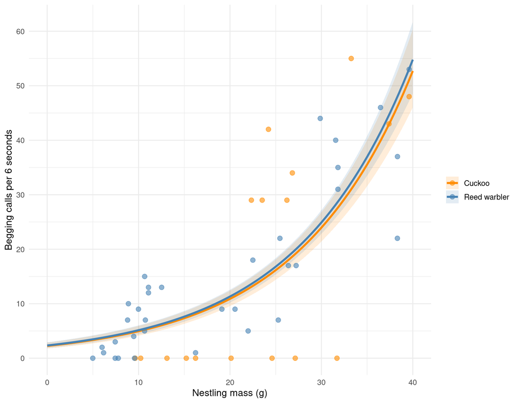

## Model checks

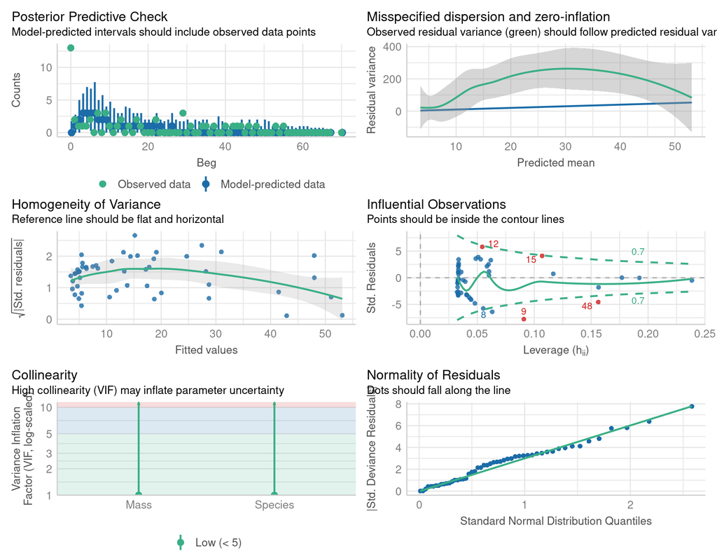

## Interaction term

```r
cuckoo_glm_interaction <- glm(Beg ~ Mass + Species+
                                Mass:Species,
                              data = cuckoo,
                          family = poisson)

summary(cuckoo_glm_interaction)
```

```
Call:
glm(formula = Beg ~ Mass + Species + Mass:Species, family = poisson,
    data = cuckoo)

Coefficients:
                     Estimate Std. Error z value Pr(>|z|)
(Intercept)          0.334475   0.227143   1.473  0.14088
Mass                 0.094847   0.007261  13.062  < 2e-16 ***
SpeciesWarbler       0.674820   0.259217   2.603  0.00923 **
Mass:SpeciesWarbler -0.021673   0.008389  -2.584  0.00978 **
---
Signif. codes:  0 '***' 0.001 '**' 0.01 '*' 0.05 '.' 0.1 ' ' 1

(Dispersion parameter for poisson family taken to be 1)

    Null deviance: 970.08  on 50  degrees of freedom
Residual deviance: 436.05  on 47  degrees of freedom
AIC: 615.83

Number of Fisher Scoring iterations: 6
```

## Interaction predictions

```r
predictions_interaction <- emmeans(cuckoo_glm_interaction,
specs = ~ Mass + Species,
at = list(Mass = seq(0, 40, by = 0.5)),
type = "response") |>
as_tibble()
```

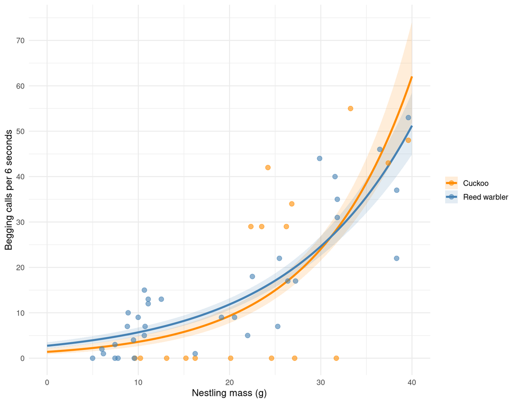

## Model check

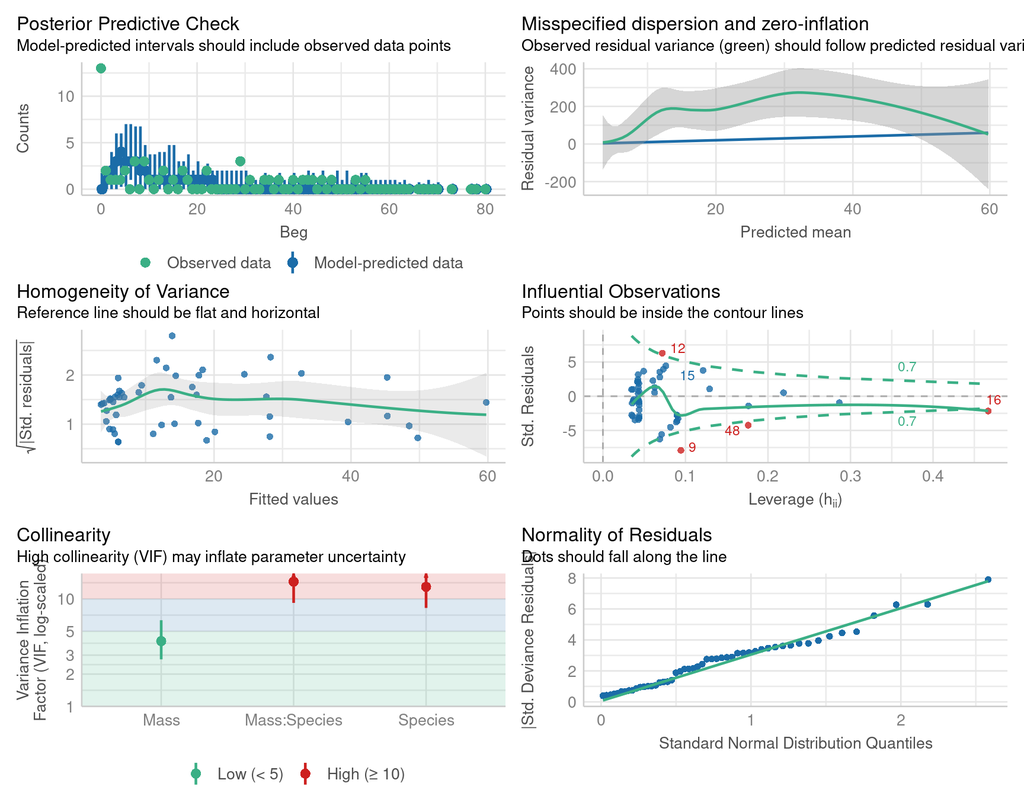

# Overdispersion

## Overdispersion

When the residual deviance is higher than the residual degrees of freedom, we say that the model is overdispersed. This situation is mathematically represented as:

$$\phi = \frac{\text{Residual deviance}}{\text{Residual degrees of freedom}}$$

Overdispersion occurs when the variance in the data is even higher than the mean, indicating that the Poisson distribution might not be the best choice. This can be due to many reasons, such as the presence of many zeros, many very high values, or missing covariates in the model.

## Overdispersion and what to do about it

Overdispersion statistic values > 1

| Causes of over-dispersion | What to do about it |
| --- | --- |
| Model mis-specification (missing covariates or interactions) | Add more covariates or interaction terms |
| Too many zeros (“zero inflation”) | Use a zero-inflated model |
| Non-independence of observations | Use a generalised mixed model with random effects to take non-independence into account |
| Variance is larger than the mean | Use a quasipoisson GLM if overdispersion = 2-15. Use a negative binomial GLM if > 15-20 |

## Overdispersion and what to do about it

- It may be true that you are initially unsure whether overdispersion is coming from zero-inflation, larger variance than the mean or both.
- You can fit models with the same dependent and independent variables and different error structures and use AIC to help determine the best model for your data
- Study the residual plots

## AIC

- The Akaike Information Criterion (AIC) balances the trade-off between model fit and complexity by penalizing models with more parameters.
- It aims to find the model that best explains the data while avoiding overfitting.
- AIC is calculated as follows: $\text{AIC} = 2k - 2\ln(\hat{L})$,
- where: log-likelihood is the maximized value of the likelihood function for the fitted model. $k$ is the number of parameters in the model.
- In general a difference in AIC of <2 suggests equivalent goodness-of-fit

## AIC

**AIC can:**

- Compare non-nested models fitted to the same dataset and response variable
- Compare across different GLM families and link functions

**AIC cannot:**

- Compare models where the response variable is transformed
- Compare models where there are differences in the dataset

## Overdispersion in the model

- Rough check

$\phi = \frac{\text{Residual deviance}}{\text{Residual degrees of freedom}}$ = $\frac{436.05}{47} = 9.27$

```r
summary(cuckoo_glm_interaction)
```

```
Call:
glm(formula = Beg ~ Mass + Species + Mass:Species, family = poisson,
    data = cuckoo)

Coefficients:
                     Estimate Std. Error z value Pr(>|z|)
(Intercept)          0.334475   0.227143   1.473  0.14088
Mass                 0.094847   0.007261  13.062  < 2e-16 ***
SpeciesWarbler       0.674820   0.259217   2.603  0.00923 **
Mass:SpeciesWarbler -0.021673   0.008389  -2.584  0.00978 **
---
Signif. codes:  0 '***' 0.001 '**' 0.01 '*' 0.05 '.' 0.1 ' ' 1

(Dispersion parameter for poisson family taken to be 1)

    Null deviance: 970.08  on 50  degrees of freedom
Residual deviance: 436.05  on 47  degrees of freedom
AIC: 615.83

Number of Fisher Scoring iterations: 6
```

```r
performance::check_overdispersion(cuckoo_glm_interaction)
```

```
# Overdispersion test

       dispersion ratio =   7.724
  Pearson's Chi-Squared = 363.036
                p-value = < 0.001
```

## Quasi-Poisson GLM

The systematic part and the link function remain the same

$$\log{\lambda} = \beta_0 + \beta_1 x_i$$

*phi*$\phi$ is a dispersion parameter, it will not affect estimates but will affect *significance*. Standard errors are multiplied by $\sqrt\phi$

$$Y_i = Poisson(\phi \lambda_i)$$

Where:

- $Yi$ is the response variable.
- $\phi$ is the dispersion parameter, which adjusts the variance of the distribution

Confidence intervals and p-values WILL change.

## Fit a quasipoisson model to the data

```r
cuckoo_glm_quasi <- glm(Beg ~ Mass + Species+
                                Mass:Species,
                              data = cuckoo,
                          family = quasipoisson)
```

- Look at the residual plots - how have they changed?
- Look at the SE and p-values - how have they changed
- Calculate new 95% confidence intervals

## Compare models

```r
summary(cuckoo_glm_interaction)
summary(cuckoo_glm_quasi)
```

```
Call:
glm(formula = Beg ~ Mass + Species + Mass:Species, family = poisson,
    data = cuckoo)

Coefficients:
                     Estimate Std. Error z value Pr(>|z|)
(Intercept)          0.334475   0.227143   1.473  0.14088
Mass                 0.094847   0.007261  13.062  < 2e-16 ***
SpeciesWarbler       0.674820   0.259217   2.603  0.00923 **
Mass:SpeciesWarbler -0.021673   0.008389  -2.584  0.00978 **
---
Signif. codes:  0 '***' 0.001 '**' 0.01 '*' 0.05 '.' 0.1 ' ' 1

(Dispersion parameter for poisson family taken to be 1)

    Null deviance: 970.08  on 50  degrees of freedom
Residual deviance: 436.05  on 47  degrees of freedom
AIC: 615.83

Number of Fisher Scoring iterations: 6
```

```
Call:
glm(formula = Beg ~ Mass + Species + Mass:Species, family = quasipoisson,
    data = cuckoo)

Coefficients:
                    Estimate Std. Error t value Pr(>|t|)
(Intercept)          0.33448    0.63129   0.530    0.599
Mass                 0.09485    0.02018   4.700  2.3e-05 ***
SpeciesWarbler       0.67482    0.72043   0.937    0.354
Mass:SpeciesWarbler -0.02167    0.02332  -0.930    0.357
---
Signif. codes:  0 '***' 0.001 '**' 0.01 '*' 0.05 '.' 0.1 ' ' 1

(Dispersion parameter for quasipoisson family taken to be 7.7242)

    Null deviance: 970.08  on 50  degrees of freedom
Residual deviance: 436.05  on 47  degrees of freedom
AIC: NA

Number of Fisher Scoring iterations: 6
```

## Interaction predictions

```r
predictions_quasi <- emmeans(cuckoo_glm_quasi,
specs = ~ Mass + Species,
at = list(Mass = seq(0, 40, by = 0.5)),
type = "response") |>
as_tibble()
```

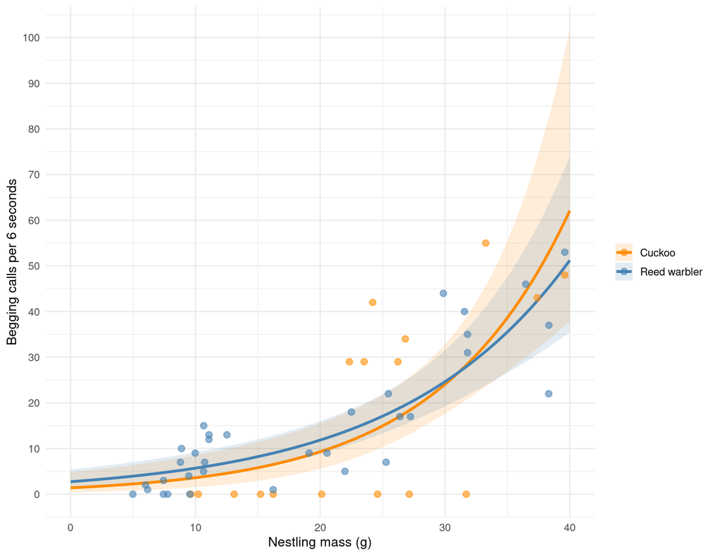

# Negative Binomial

## Negative Binomial

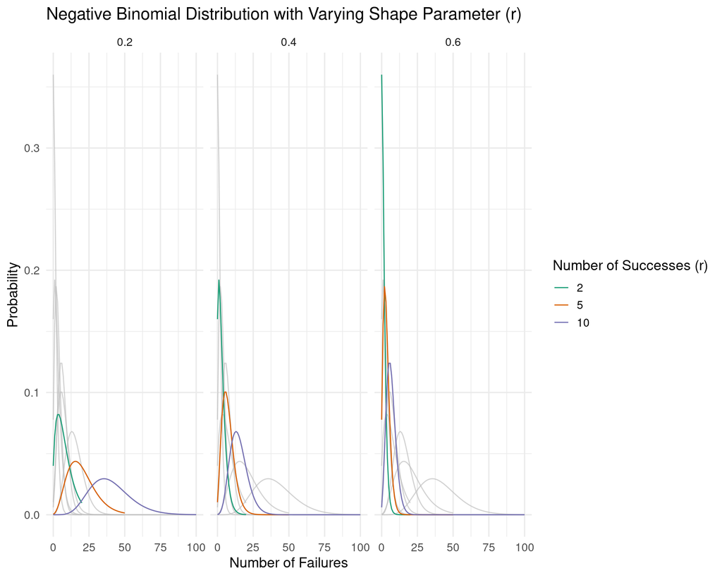

## Negative Binomial

Negative binomial GLMs are favored when overdispersion is high.

It has two parameters, $μ$ and $\theta$. $\theta$ controls for the dispersion parameter (smaller $\theta$ indicates higher dispersion). It corresponds to a combination of two distributions (Poisson and gamma).

It assumes that the $Y_i$ are Poisson distributed with the mean $μ_i$ assumed to follow a gamma distribution:

$$E(Y_i) = μ_i \\
\text{Var}(Y_i) = μ_i + μ_i^2/k$$

## Fitting a negative binomial in R

Negative binomial is not in the `glm()` function. We need the `MASS` package:

Suitable for strongly over-dispersed zero-bounded integer data.

```r
library(MASS)

model <- glm.nb(y ~ x1 + x2, link = "log", data = dataframe)
```

## Negbin

```r
# Neg bin
cuckoo_nb <- glm.nb(Beg ~ Mass + Species+
                                Mass:Species,
                              data = cuckoo,
                    link = "log")
summary(cuckoo_nb)
```

```
Call:
glm.nb(formula = Beg ~ Mass + Species + Mass:Species, data = cuckoo,
    link = "log", init.theta = 0.9028849768)

Coefficients:
                    Estimate Std. Error z value Pr(>|z|)
(Intercept)         -2.21359    0.91829  -2.411  0.01593 *
Mass                 0.19140    0.03463   5.527 3.26e-08 ***
SpeciesWarbler       3.09452    0.99572   3.108  0.00188 **
Mass:SpeciesWarbler -0.11269    0.03868  -2.913  0.00358 **
---
Signif. codes:  0 '***' 0.001 '**' 0.01 '*' 0.05 '.' 0.1 ' ' 1

(Dispersion parameter for Negative Binomial(0.9029) family taken to be 1)

    Null deviance: 98.183  on 50  degrees of freedom
Residual deviance: 60.376  on 47  degrees of freedom
AIC: 357.3

Number of Fisher Scoring iterations: 1

              Theta:  0.903
          Std. Err.:  0.226

 2 x log-likelihood:  -347.296
```

## Compare models

## Compare models

```r
AIC(cuckoo_glm_interaction)
```

```
[1] 615.8282
```

```r
AIC(cuckoo_glm_quasi)
```

```
[1] NA
```

```r
AIC(cuckoo_nb)
```

```
[1] 357.2955
```

## Validating Negative Binomial models

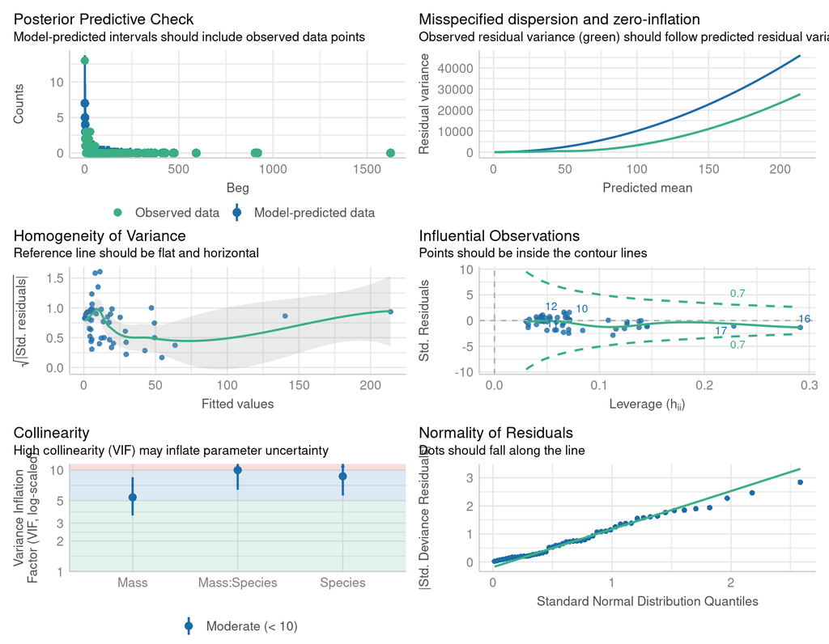

```
# Check for zero-inflation

   Observed zeros: 13
  Predicted zeros: 7
            Ratio: 0.56
```

```r
performance::check_model(cuckoo_nb,
                         residual_type = "normal",
            detrend = FALSE)
performance::check_zeroinflation(cuckoo_nb)
```

## Comparison of model predictions

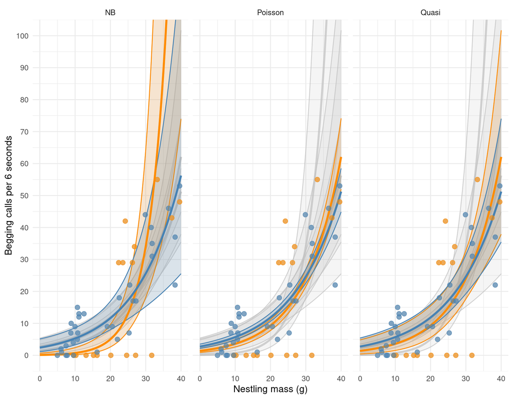

# What next?

## Model limitations

- There are series of models that can deal with zero-inflation
- Pick the best model for your needs and understand limitations
- Recognise that terms may be *significant* or not depending on modelling decisions
- Be transparent about modelling decisions

## Write-ups

Begging call rates increased with nestling mass for both species. There was weak evidence that this relationship differed between species as our interaction term was significant under the Poisson GLM (Mass × Species interaction: z = -2.58, P = 0.009, n = 51). When accounting for overdispersion with quasi-Poisson this effect was not significant (Mass × Species interaction: t(47) = -.93, P = 0.357), but remains so under a Negative Binomial model (z = -2.913, P = 0.004). Given this uncertainty, we present both specifications here.

## Tables

```r
sjPlot::tab_model(cuckoo_glm_additive, cuckoo_glm_quasi, cuckoo_nb)
```

|  | Beg |  |  | Beg |  |  | Beg |  |  |
| --- | --- | --- | --- | --- | --- | --- | --- | --- | --- |
| Predictors | Incidence Rate Ratios | CI | p | Incidence Rate Ratios | CI | p | Incidence Rate Ratios | CI | p |
| (Intercept) | 2.25 | 1.77 – 2.85 | **<0.001** | 1.40 | 0.37 – 4.47 | 0.596 | 0.11 | 0.01 – 1.39 | **0.016** |
| Mass | 1.08 | 1.07 – 1.09 | **<0.001** | 1.10 | 1.06 – 1.15 | **<0.001** | 1.21 | 1.10 – 1.37 | **<0.001** |
| Species [Warbler] | 1.04 | 0.90 – 1.20 | 0.591 | 1.96 | 0.50 – 8.54 | 0.349 | 22.08 | 1.54 – 442.56 | **0.002** |
| Mass × Species [Warbler] |  |  |  | 0.98 | 0.93 – 1.02 | 0.353 | 0.89 | 0.79 – 0.99 | **0.004** |
| Observations | 51 |  |  | 51 |  |  | 51 |  |  |
| R<sup>2</sup> Nagelkerke | 1.000 |  |  | 1.000 |  |  | 0.613 |  |  |